# Portfolio 1 — Experimental Methods 1 2019

Jesper Fischer Ehmsen

02/10/2019

```r
knitr::opts_chunk$set(echo = TRUE, include = TRUE)
```

## Portfolio exam - Part 1

#### Write a short data mining report on the CogSci Intro Week Personality Test Data in which you answer the following questions in prose, code and graphs:

First of all, you have to import the personality data. If the dataset is in your working directory, then you can just load it into R. Otherwise you will have to change your working directory.

```r
setwd("C:/Users/User/Desktop/cog sci/ExpMeth1---assignment-1")
personality = read.csv("NEW_CogSciPersonalityTest2019.csv")
library(tidyverse)
library(pastecs)
```

Once you are done loading the data, you can start working on the questions below.

#### Question 1

Who can hold their breath longer on average, those with right or left ocular dominance? Plot the data using ggplot2 to find out. The plots should include error bars (depicting the standard error of the means). Then use the mean() and sd() functions to find mean and standard deviation of the two eye dominance groups.

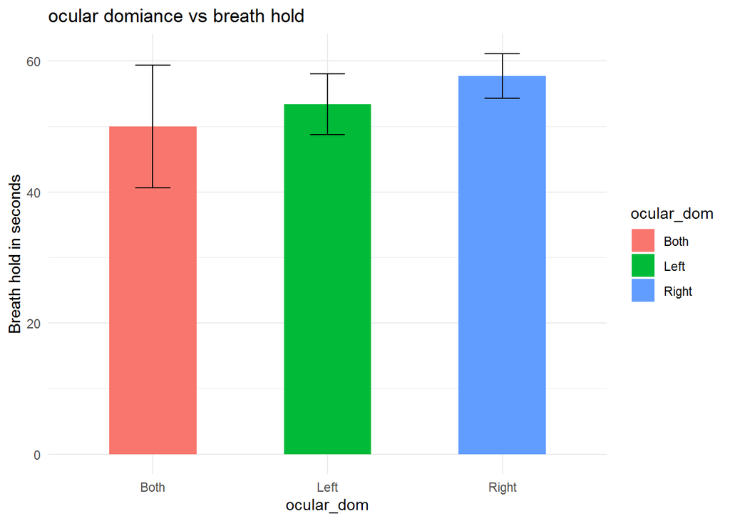

```r
ggplot(personality, aes(x=personality$ocular_dom, y=personality$breath_hold, fill = ocular_dom))+
  geom_bar(stat='summary', fun.y = mean, width = 0.5)+
  geom_errorbar(stat = 'summary', fun.data = mean_se, width = 0.2)+
  labs(x = "ocular_dom", y = "Breath hold in seconds")+
  ggtitle("ocular domiance vs breath hold")+theme_minimal()
```

```r
personality %>% group_by(personality$ocular_dom) %>% summarise(mean(breath_hold))
```

```
## # A tibble: 3 x 2
##   `personality$ocular_dom` `mean(breath_hold)`
##   <fct>                                  <dbl>
## 1 Both                                    50
## 2 Left                                    53.4
## 3 Right                                   57.7
```

```r
personality %>% group_by(personality$ocular_dom) %>% summarise(sd(breath_hold))
```

```
## # A tibble: 3 x 2
##   `personality$ocular_dom` `sd(breath_hold)`
##   <fct>                                <dbl>
## 1 Both                                  18.7
## 2 Left                                  21.3
## 3 Right                                 20.6
```

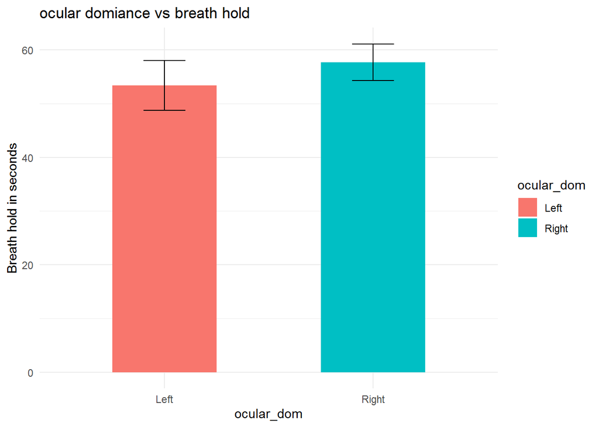

```r
#because the question at hand was about left or right ocualar dominance here is a histogram with only them.

subsettet_ocular_dom = subset(personality, personality$ocular_dom == "Right" | ocular_dom == "Left")

ggplot(subsettet_ocular_dom, aes(x=subsettet_ocular_dom$ocular_dom, y=subsettet_ocular_dom$breath_hold, fill = ocular_dom))+
  geom_bar(stat='summary', fun.y = mean, width = 0.5)+
  geom_errorbar(stat = 'summary', fun.data = mean_se, width = 0.2)+
  labs(x = "ocular_dom", y = "Breath hold in seconds")+
  ggtitle("ocular domiance vs breath hold")+theme_minimal()
```

```r
subsettet_ocular_dom %>% group_by(subsettet_ocular_dom$ocular_dom) %>% summarise(mean(breath_hold))
```

```
## # A tibble: 2 x 2
##   `subsettet_ocular_dom$ocular_dom` `mean(breath_hold)`
##   <fct>                                           <dbl>
## 1 Left                                             53.4
## 2 Right                                            57.7
```

```r
subsettet_ocular_dom %>% group_by(subsettet_ocular_dom$ocular_dom) %>% summarise(sd(breath_hold))
```

```
## # A tibble: 2 x 2
##   `subsettet_ocular_dom$ocular_dom` `sd(breath_hold)`
##   <fct>                                         <dbl>
## 1 Left                                           21.3
## 2 Right                                          20.6
```

Explain your results in plain terms here: The average length people with right ocular domiance(ROD) could hold their breath was 57.7 seconds, while people with left ocular dominance(LOD) could hold their breath for 53.4 seconds on average. The standard diviation for the ROD group was 20.6 seconds, meaning that the data-points were quite spread out from the mean. This basically means that some people had really low scores compared to the mean, while others had really high scores compared to the mean. This explaination is also applicable for the LOD group since their standard diviation was 21.3 seconds.

This means that on average people with ROD can hold their breath slightly longer than those with LOD for this sample, eventhough there are alot of variation between people hence the high standard diviations.

If we wanted to generalize this to the whole population, which we might define as university students then we would have to look at the standard error which is displayed on the histogram as the errorbars which rise above and into the bars. As we can see these bars rise quite abit above the bars which indicate that this sample might not be that representative of the whole population.

#### Question 2

Who likes silence vs. noise best? Males or females? Also in this case you should plot the data using ggplot2 (including error bars), then use the mean() and sd() functions to find mean and standard deviation of the two genders.

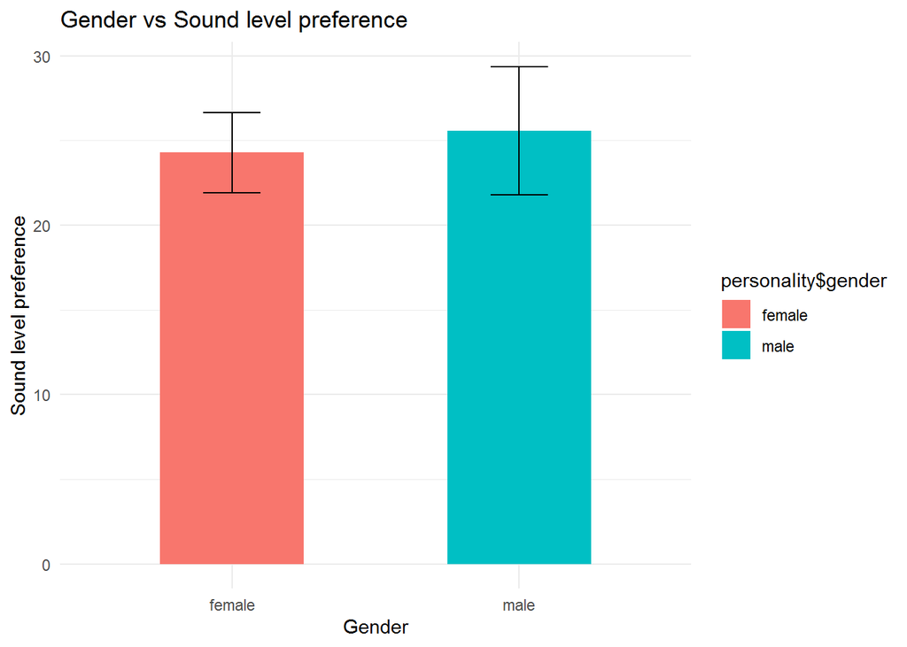

```r
ggplot(personality, aes(x=personality$gender, y=personality$sound_level_pref, fill = personality$gender))+
  geom_bar(stat='summary', fun.y = mean, width = 0.5)+
  geom_errorbar(stat = 'summary', fun.data = mean_se, width = 0.2)+
  labs(x = "Gender", y = "Sound level preference")+
  ggtitle("Gender vs Sound level preference")+theme_minimal()
```

```r
personality %>% group_by(personality$gender) %>% summarise(mean(sound_level_pref))
```

```
## # A tibble: 2 x 2
##   `personality$gender` `mean(sound_level_pref)`
##   <fct>                                   <dbl>
## 1 female                                   24.3
## 2 male                                     25.6
```

```r
personality %>% group_by(personality$gender) %>% summarise(sd(sound_level_pref))
```

```
## # A tibble: 2 x 2
##   `personality$gender` `sd(sound_level_pref)`
##   <fct>                                 <dbl>
## 1 female                                 14.6
## 2 male                                   18.5
```

Explain your results in plain terms here:

The average male prefered a sound level of 25.6 while females prefered a sound level of 24.3 on average. The standard diviation for the males was 18.5, meaning that the data-points were really spread out from the mean since the mean only was 25.6, which ultimatly means that people had really speard out results, some prefered really quiet sounds, while others prefered really loud sounds compared to the mean. This explaination is also applicable for the female group since their standard diviation also was quite high at 14.6, the lower value here indicates that the females on average prefered sounds that were closer the mean of 24.3 than the males.

The results imply that on average males like louder sounds than females but only by a tiny margin, however the females tended to be closer to the average indicating that there is more variation in the males, in this data-set there was huge variation between data-points, hence the really big standard diviation, compared to the mean

Again if we wanted to generalize this to the whole population, which we might define as university students, then we would have to look at the standard error which is displayed on the histogram as the errorbars which rise above and into the bars. As we can see these bars rise quite abit above the bars and even more so than in exercise 1, which indicate that this sample is even less representative of the whole population than the sample collected in exercise 1.

#### Question 3

Are the breath_hold data normally distributed? Provide visual and numeric support for your answer.

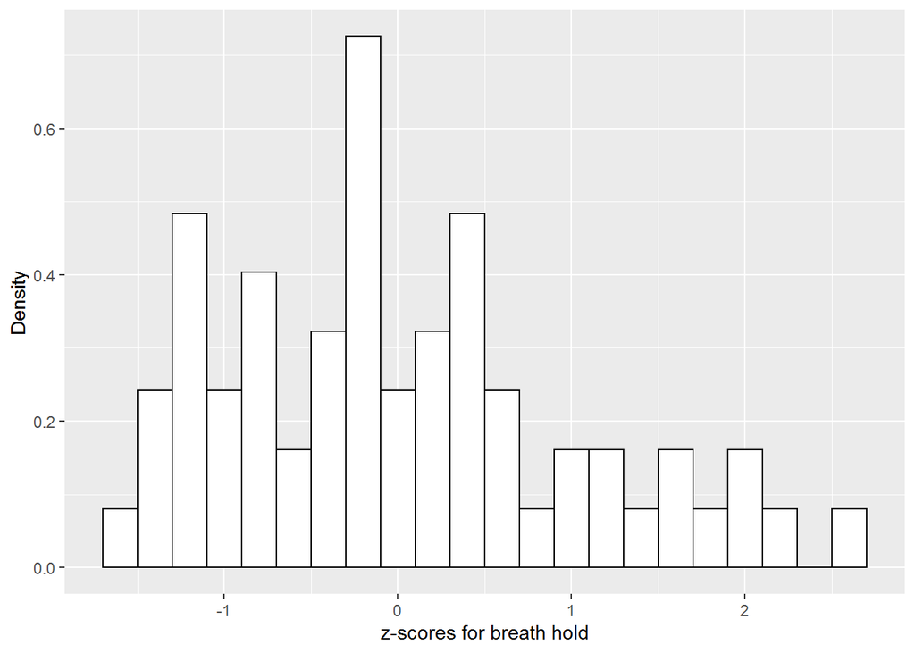

```r
#checking for outliers (-3 < z < 3):
personality$zscores_breath = (personality$breath_hold-mean(personality$breath_hold))/sd(personality$breath_hold)

ggplot(personality, aes(personality$zscores_breath)) + geom_histogram(aes(y=..density..), colour = "black", fill = "white", binwidth = 0.2) + labs(x ="z-scores for breath hold", y = "Density")
```

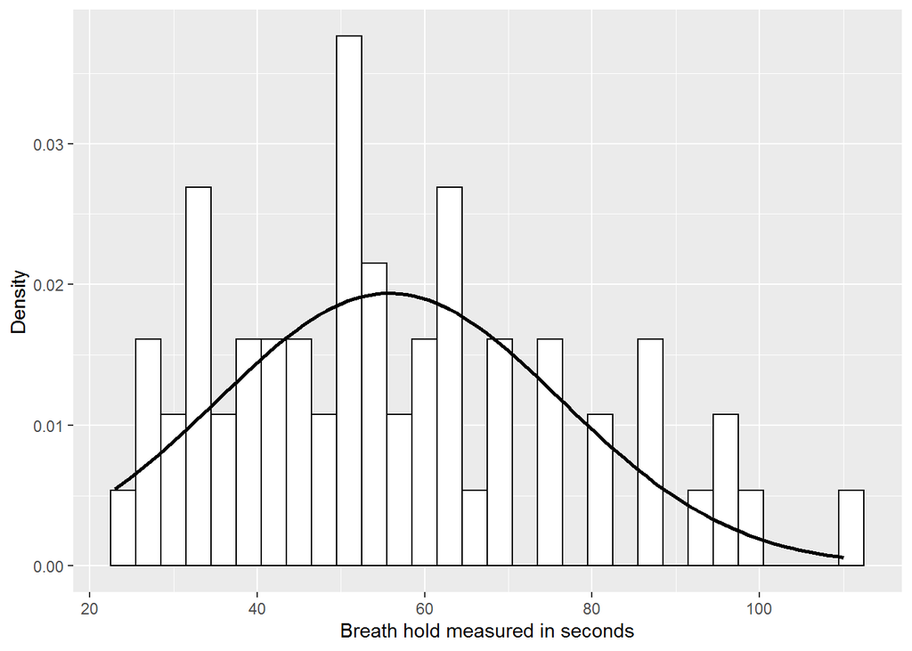

```r
ggplot(personality, aes(breath_hold)) + geom_histogram(aes(y=..density..), colour = "black", fill = "white", binwidth = 3) + labs(x ="Breath hold measured in seconds", y = "Density") + stat_function(fun = dnorm, args = list(mean = mean(personality$breath_hold), sd = sd(personality$breath_hold)), colour= "black", size = 1)
```

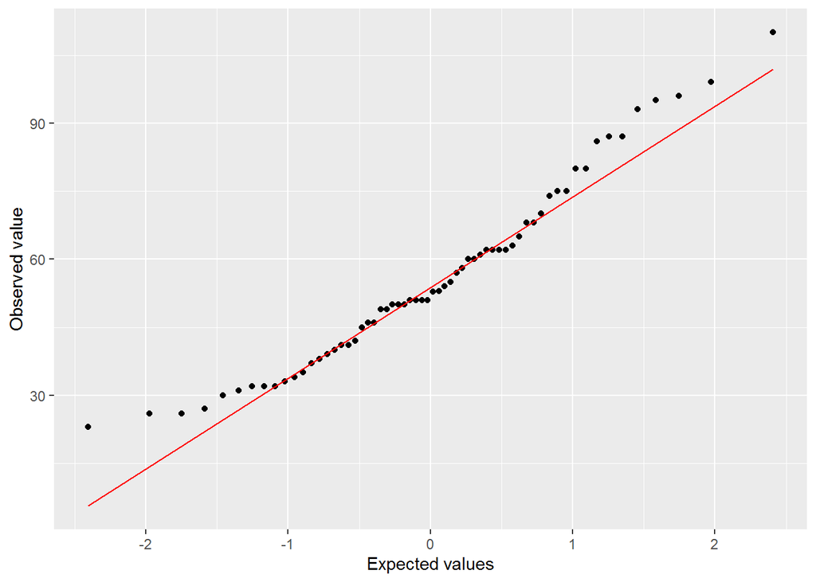

```r
qplot(sample = personality$breath_hold, stat="qq")+ xlab("Expected values") + ylab("Observed value")+stat_qq()+stat_qq_line(colour = "red")
```

```r
round(stat.desc(personality$breath_hold, basic = FALSE, norm = TRUE), digit = 3)
```

```
##       median         mean      SE.mean CI.mean.0.95          var
##       51.905       55.771        2.613        5.226      423.474
##      std.dev     coef.var     skewness     skew.2SE     kurtosis
##       20.578        0.369        0.580        0.954       -0.359
##     kurt.2SE   normtest.W   normtest.p
##       -0.299        0.959        0.035
```

Explain your results in plain terms here: Firstly to check if the if the data-set was normally distrubuted, it was checked wether or not there was any outliers, which is difined as having a z-score of 3 or above or -3 or below. It is visually clear that no such outlier exists in our data-set, there is a data-point with a z-score of around 2.5, which indicates that this score is far from the mean, but we can’t categorize that as an outlier.

by just looking at the distrubution one can see that it doesn’t quite look like a normal distrubution, but kind of close. It is also visable that the model (the normal distrubution), is a little right/positivly skewed.

The Q-Q plot tells us the same story that the data-points aren’t quite on a perfect line but they do follow a close to linear pattern, which indicates that the data is approximating a normal distrubution.

The values for skew.2SE and kurt.2SE should both be as close to 0 as possible for it to be a perfectly normal distrubution. The general consensus is that if -1 > skew.2SE > 1 then we would say that the data is normally distributed. We can see that our skew.2SE value is slightly below 1 which indates that this data-set is approximating a normal distrubution, and the kurt.2SE is also fairly close to 0.

Lastly for determining wether the data-set can be interpreted as a normal distrubution would be to look at the shaprio-wilks test. This test compares your normal distrubution to a perfect normal distrubution and calculates wether there is a significant difference between the two. if p<0.05 then one would say that there is a significant difference which would mean that the distrubution isn’t normal. The test gives a p-value of 0.035 which is less than 0.05 indicating that the data-set is not normally distrubuted.

With all these tests in mind one could reasonably assume that the data-set is normally distrubuted, even though the shaprio wilks test showed that the distrubution is significantly different than a perfect normal distrubution, one might assume this because the other tests indicated that the data-set is normally distrubuted and adding to that the shaprio-wilks test was really close to being non-significant, 0.035 is close to 0.05.

#### Question 4

Are the Balloon reaction time data (balloon and balloon_balance) normally distributed? Provide visual and numeric support for your answer.

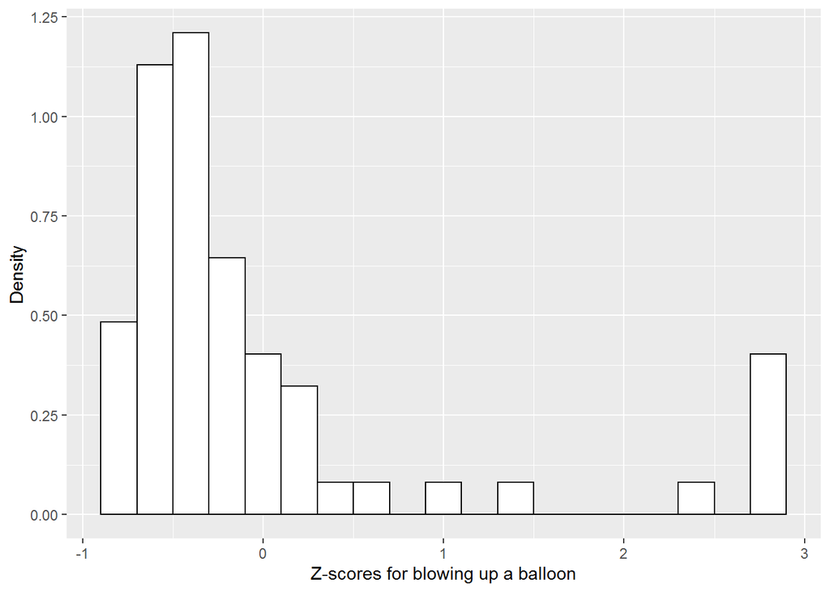

```r
#lets see if there is an outlier.
personality$zscores_balloon = (personality$balloon-mean(personality$balloon))/sd(personality$balloon)

ggplot(personality, aes(personality$zscores_balloon)) + geom_histogram(aes(y=..density..), colour = "black", fill = "white", binwidth = 0.2) + labs(x ="Z-scores for blowing up a balloon", y = "Density")
```

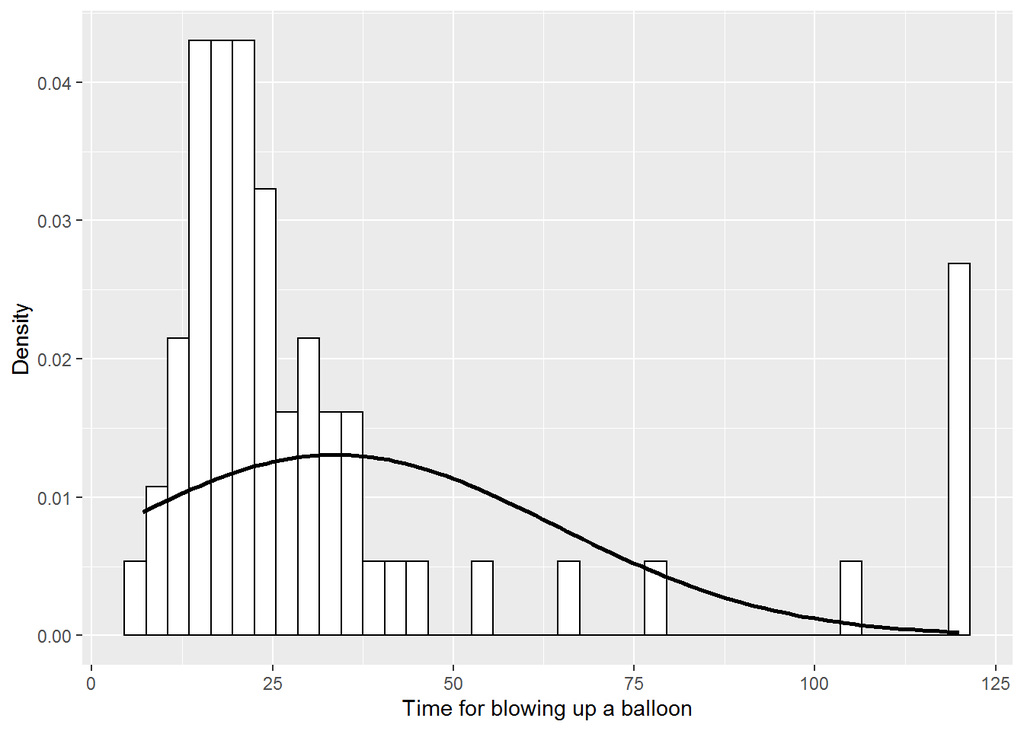

```r
ggplot(personality, aes(personality$balloon)) + geom_histogram(aes(y=..density..), colour = "black", fill = "white", binwidth = 3) + labs(x ="Time for blowing up a balloon", y = "Density") + stat_function(fun = dnorm, args = list(mean = mean(personality$balloon), sd = sd(personality$balloon)), colour= "black", size = 1)
```

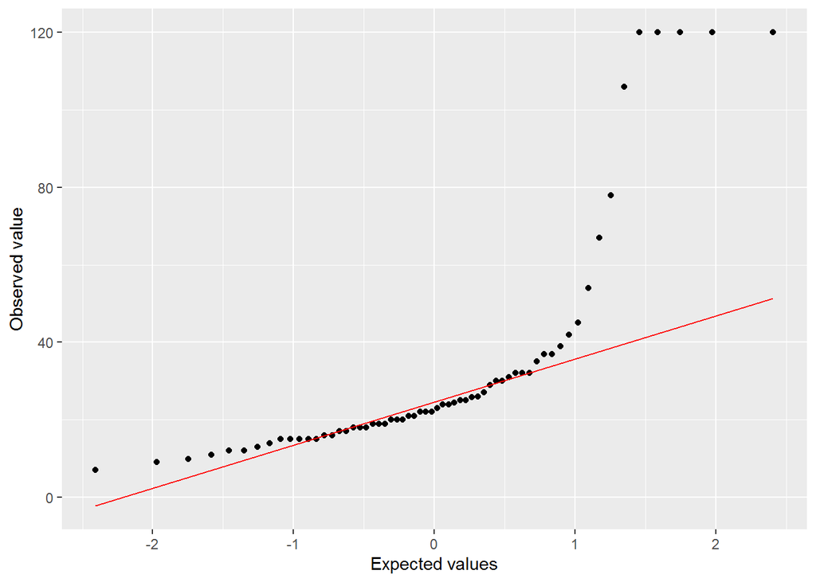

```r
qplot(sample = personality$balloon, stat="qq")+ xlab("Expected values") + ylab("Observed value")+stat_qq_line(colour = "red")
```

```r
round(stat.desc(personality$balloon, basic = FALSE, norm = TRUE), digit = 11)
```

```
##       median         mean      SE.mean CI.mean.0.95          var
## 2.250000e+01 3.367742e+01 3.873823e+00 7.746187e+00 9.304031e+02
##      std.dev     coef.var     skewness     skew.2SE     kurtosis
## 3.050251e+01 9.057259e-01 2.009620e+00 3.306361e+00 2.851779e+00
##     kurt.2SE   normtest.W   normtest.p
## 2.379306e+00 6.603509e-01 1.100000e-10
```

Explain your results in plain terms here:

Firstly one would check if there is any outliers again. In this plot with the z-scores on the x-axis, it is clearly visable that there is a couple of data-points that have high z-scores around 2.8 but non of them above 3. This cluster at the end is probably due to a celling in the experiment, the longest one could take to blow up a balloon was 120 seconds.

by just looking at the distrubution we can see that it doesn’t look like a normal distrubution. It is visable that the model (the normal distrubution), is right/positivly skewed.

The Q-Q plot tells us the same story that the data-points aren’t on a staight line neither do they follow a linear pattern, which indicates that the data isn’t normally distrubuted

We can see that the skew.2SE value is way above 1, it is 3.3 which indates that this data-set isn’t normally distrubuted, and the kurt.2SE is also far off 0.

Lastly the shapiro wilks test shows in this case that the data-set isn’t normally distrubuted, since the incredibly low p-value which is 0.00000000011.

With all these tests in mind one could reasonably assume that the data-set isn’t normally distrubuted.

looking at the balloon_balance data next:

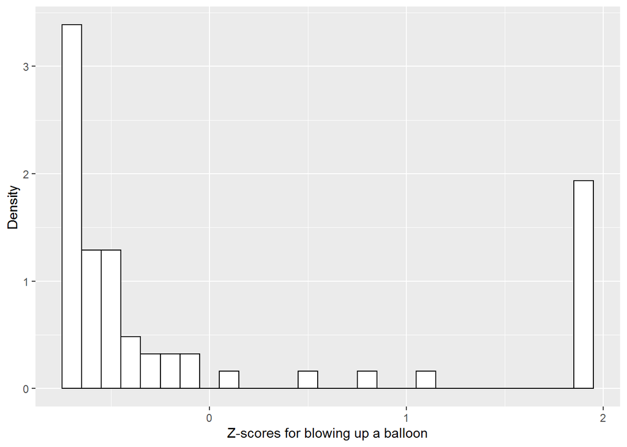

```r
#checking for outliers:
personality$zscores_balloon_balance = (personality$balloon_balance-mean(personality$balloon_balance))/sd(personality$balloon_balance)

ggplot(personality, aes(personality$zscores_balloon_balance)) + geom_histogram(aes(y=..density..), colour = "black", fill = "white", binwidth = 0.1) + labs(x ="Z-scores for blowing up a balloon", y = "Density")
```

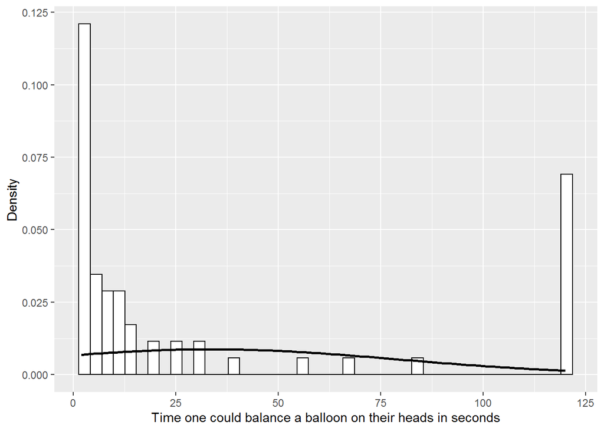

```r
ggplot(personality, aes(personality$balloon_balance)) + geom_histogram(aes(y=..density..), colour = "black", fill = "white", binwidth = 2.8) + labs(x ="Time one could balance a balloon on their heads in seconds", y = "Density") + stat_function(fun = dnorm, args = list(mean = mean(personality$balloon_balance), sd = sd(personality$balloon_balance)), colour= "black", size = 1)
```

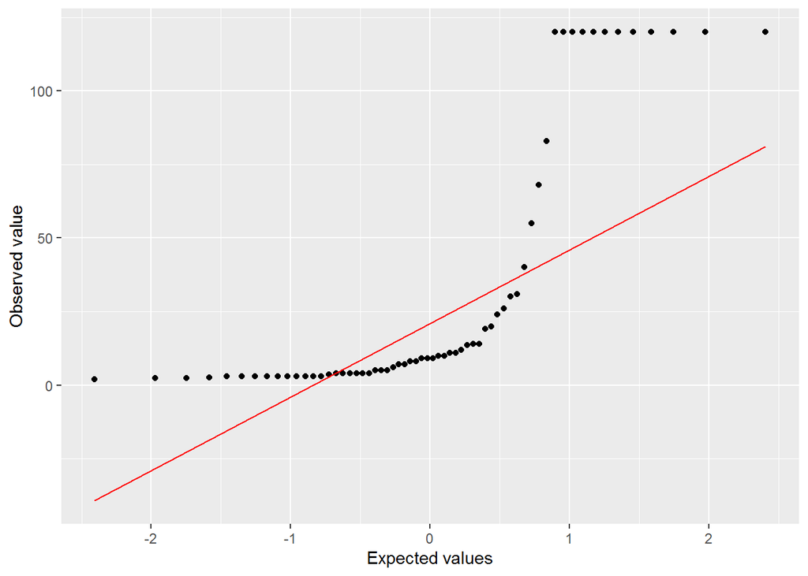

```r
qplot(sample = personality$balloon_balance, stat="qq")+ xlab("Expected values") + ylab("Observed value")+stat_qq_line(colour = "red")
```

```r
round(stat.desc(personality$balloon_balance, basic = FALSE, norm = TRUE), digit = 11)
```

```
##        median          mean       SE.mean  CI.mean.0.95           var
##  9.000000e+00  3.349000e+01  5.754420e+00  1.150667e+01  2.053028e+03
##       std.dev      coef.var      skewness      skew.2SE      kurtosis
##  4.531035e+01  1.352952e+00  1.224816e+00  2.015148e+00 -3.028144e-01
##      kurt.2SE    normtest.W    normtest.p
## -2.526451e-01  6.531113e-01  8.000000e-11
```

Explain your results in plain terms here:

Again it is visable that there are no outliers, but it does however seem that there is a celling like in the previous experiment.

by just looking at the distrubution we can see that it doesn’t look like a normal distrubution. It is visable that the model (the normal distrubution), is right/positivly skewed.

The Q-Q plot tells us the same story that the data-points aren’t on a staight line neither do they follow a linear pattern, which indicates that the data isn’t normally distrubuted

We can see that the skew.2SE value is way above 1, it is 2.015 which indates that this data-set isn’t normally distrubuted, the kurt.2SE score isn’t that far off 0 at -0.253. but this has to be seen in the context of the other tests.

Lastly the shapiro wilks test shows in this case that the data-set isn’t normally distrubuted, since the incredibly low p-value which is 0.00000000008.

With all these tests in mind one could reasonably assume that the data-set isn’t normally distrubuted.

#### Question 5

Shoe size could tell us something about general body size, which could also be connected to one’s ability to hold your breath. In other words we predict that there is a positive relation between shoe size and how long time CogSci students can hold their breath. Try plotting the two sets of data against each other using a scatter plot (hint: both variables are continuous variables). Bonus question: Males and females have different body sizes. Use grouping in your plot to distinguish the relationship between shoe size and holding breath for males and females.

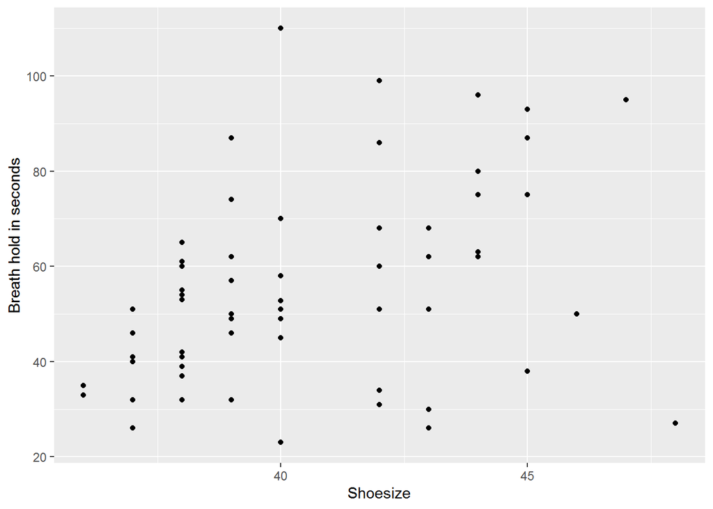

```r
ggplot(personality, aes(x = personality$shoesize, y = personality$breath_hold))+geom_point()+labs(x = "Shoesize", y = "Breath hold in seconds")
```

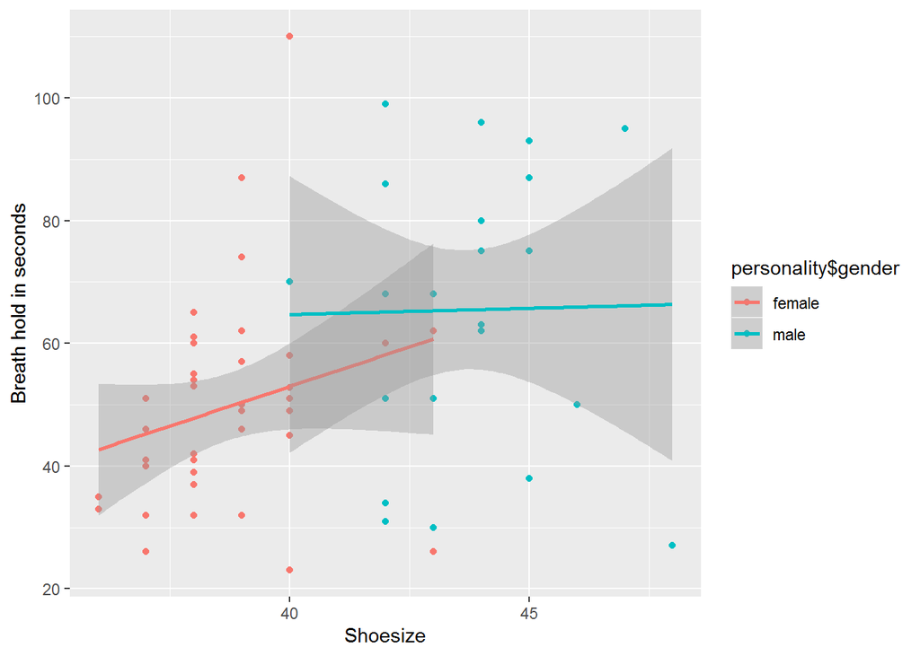

```r
#bonus question:
ggplot(personality, aes(x = personality$shoesize, y = personality$breath_hold, colour = personality$gender))+geom_point()+geom_smooth(method = lm)+labs(x = "Shoesize", y = "Breath hold in seconds")
```

Explain your results in plain terms here: The first plot shows the relationsship between shoesize and the time a cog-sci stundent could hold their breath. It is possible to see that there is a linear relationsship, at least between the people with small showsizes, between these two varibles(shoesize and their ability to hold their breath), meaning as shoesize increases so does the time a cog-sci student can hold their breath.

Looking at the second plot we can see that the isn’t a linear relationsship for the males, which is shown by a flat blue line. These results indicate that for males there is no relationsship between shoesize and how long one could hold their breath. Here one should also look at the confidence interval (the shaded grey area) which is pretty big, which indicate that we would need a bigger sample size, to confirm the results. For the females one can clearly see that there is a linear relationsship between shoesize and how long they could hold their breath, this relationsship is shown by the red line. It is also visable that the 95% confidence interval is smaller than that for the male, indicating that this sample is more indicative of the popluation it is representing.

The plots show a clear linear relationsship between shoesize and how long females could hold their breath, the plots indicate that this relationsship isn’t found in males, but with much wider confidence intervals, indicating we would need a bigger sample size to be sure of this observation.